# Ridgeline Plot Nasıl Oluşturulur?

**Veri görselleştirme** ile ilgili kanal ve siteleri takip ediyorsanız, bu özel yoğunluk grafiğine bir şekilde rastlamışsınızdır. Popülaritesi gittikçe artan bu gösterimde, farklı kategorik parametrelere ait dağılım grafikleri üstüste eklenerek, kısmi bir 3 boyutlu grafik oluşturulabiliyor.

Bu gösterim yöntemine ilk başta **Joyplot** adı verilse de, adı sonrada ilginç bir sebeple değiştiriliyor. Yöntemin ilk uygulandığı zamanlarda, Joy Division adlı müzik grubunun 1979 yılında çıkardığı Unknown Pleasures adlı albümün kapağına benzerliği üzerine **Joyplot** adı verilen grafik, sonradan isim değiştirmek zorunda kalıyor. “**Joy Division**” adlı grubun adının, aslında Nazi kamplarında köle olarak çalıştırılan yahudi kadınlara verilen isim olduğunu sonradan farkedilmesi. Bu sebeple artık, joyplot yerine **ridgeline plot** olarak adlandırılıyor.

# Kurulum:

Ridgeline Plot paketi, ggplot ile birlikte çalıştığı için beraberinde ggplot2 paketinin de kurulu olması gerekiyor.

```r
install.packages("ggridges")
install.packages("ggplot2")
```

```r
library("ggplot2")
library("ggridges")
```

# Uygulama

Önce temel bir grafik oluşturalım. Bunun için R’ın dahili verisetlerinden **iris**‘i kullanacağız. Bu veriseti, 3 farklı bitki türüne (*setosa*, *versicolor*, *virginica*) ait yaprakların boyut bilgilerini içeriyor. Önce verisetimize kısaca göz atalım.

```r
head(iris)
```

```
##   Sepal.Length Sepal.Width Petal.Length Petal.Width Species
## 1          5.1         3.5          1.4         0.2  setosa
## 2          4.9         3.0          1.4         0.2  setosa
## 3          4.7         3.2          1.3         0.2  setosa
## 4          4.6         3.1          1.5         0.2  setosa
## 5          5.0         3.6          1.4         0.2  setosa
## 6          5.4         3.9          1.7         0.4  setosa
```

Aşağıdaki örnekte, önce `ggplot()` fonksiyonunu çağırıyoruz. Ardından data parametresi ile analiz yapacağımız data.frame’i belirliyoruz. x ekseninde dağılımını görmek istediğimiz sayısal değeri, y ekseninde ise gruplandırma yapacağımız kategorik değeri belirtiyoruz. Son olarak, ridgeline katmanını `geom_density_ridges()` ile ekliyoruz.

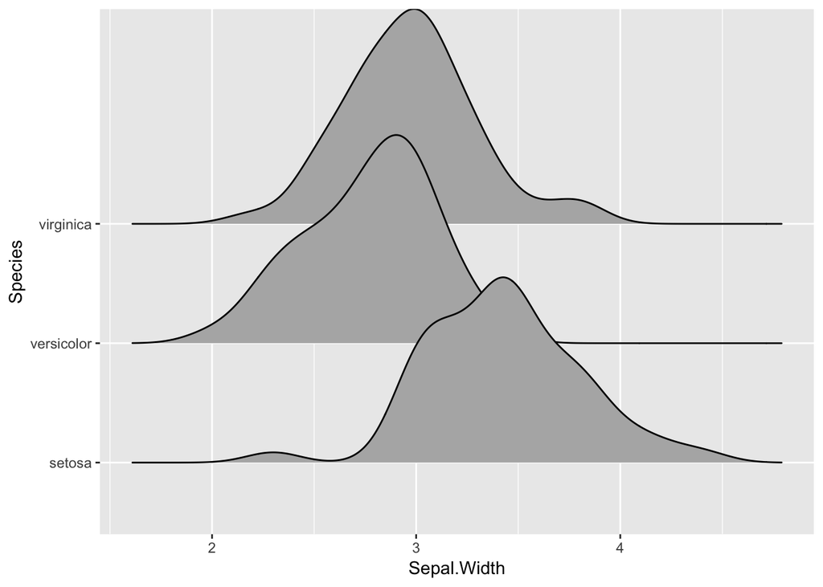

```r
# Örnek 1: Basit Yoğunluk Dağılımı
ggplot(data = iris, aes(x=Sepal.Width, y=Species)) +
    geom_density_ridges()
```

Grafik şimdiden güzel gözükse de birkaç görsel değişiklik yapmakta fayda var. Grafiğin kenar kısımlarında gereksiz boşluklar yer alıyor. Ve arkada klasik gri arkaplan var. Bunlardan kurtulalım.

Paket ile birlikte ön ayarlı bir tema da geliyor. Bu tema, ridgeline grafikleri için optimize edilmiş, görselleştirme özelliklerini (beyaz arkaplan vs.) içinde barındırıyor. `theme_ridges()` kodu ile tema katmanını ekliyoruz. Bunu eklediğinizde otomatik olarak arkaplan kaldırılıyor ve çok sayıda görsel düzeltme yapılıyor.

Boşlukları azaltmak için `scale_y_discrete` ve `scale_x_continuous` komutlarını kullanıyoruz. Esasında bu iki komut, eksenlerin sınırlarını belirlemek için kullanılıyor. Örneğin `scale_x_continuous(limits = c(2, 6))` dediğinizde x eksenindeki 2 ve 6 arası değerler yer alıyor. Biz ise `expand` parametresi ile eksen sınırlarının ölçülen değerlere yakın olmasını istiyoruz. `expand = c(0.01, 0)` komutu şunu ifade ediyor: Eksenin sınırlarını, grafik değerlerinin 0.01 katı uzaklığı + 0 birim kadar geniş tut.

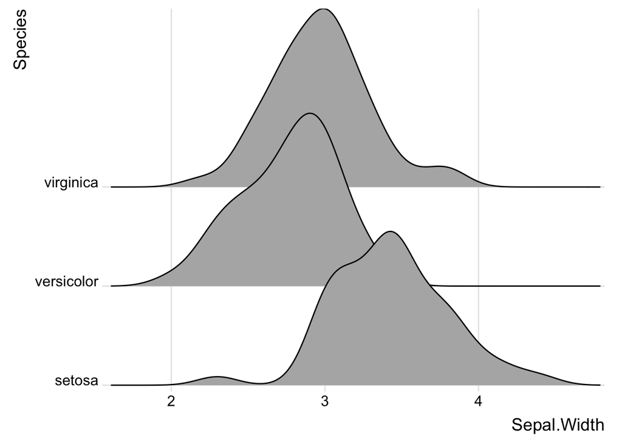

```r
# Örnek 2: Basit Tema Değişiklikleri
ggplot(data = iris, aes(y=Species, x=Sepal.Width)) +
    geom_density_ridges() +
    theme_ridges()+
    scale_y_discrete(expand = c(0.01, 0)) +
    scale_x_continuous(expand = c(0.01, 0))
```

Ridgeline gösterim şeklinin en karakteristik özelliği, üstüste binen dağılım grafikleri. Grafiklerin ne oranda üstüste bineceği (veya binmemesi) `scale` parametresi ile belirleniyor. Scale değeri ne kadar yüksekse o kadar büyük tepeler oluşturuluyor. Çoğu durumda, üstüste binen dağılımları daha güzel gözükmesi için `alpha` parametresi ile biraz şeffaflık ekleyebiliriz.

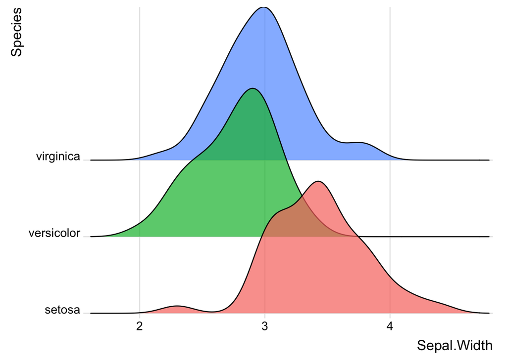

```r
# Örnek 3: İleri Tema Değişiklikleri
ggplot(data = iris, aes(y=Species, x=Sepal.Width, fill=Species)) +
    geom_density_ridges(alpha=0.7, scale=2) +
    scale_y_discrete(expand = c(0.01, 0)) +
    scale_x_continuous(expand = c(0.01, 0)) +
    theme_ridges() +
    theme(legend.position = "none")
```

Yoğunluk grafiklerinin yanı sıra, çubuk formatında ardışık histogramlar da oluşturulabiliyor. Bunun için, `stat` parametresini “binline” olarak belirlemeniz yeterli. Çubuk sayısını da `bins` parametresi ile belirtebilirsiniz.

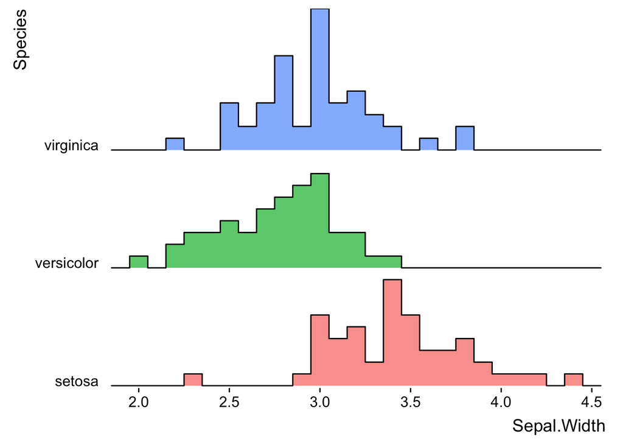

```r
# Örnek 4: Çubuk Tipi Histogram Oluşturmak
ggplot(data = iris, aes(y=Species, x=Sepal.Width, fill=Species)) +
  geom_density_ridges(alpha=0.7, scale=1.2, stat = "binline",  bins=25) +
  scale_y_discrete(expand = c(0.01, 0)) +
  scale_x_continuous(expand = c(0.01, 0)) +
  theme_ridges(grid = F) +
  theme(legend.position = "none")
```

Şimdi paketi daha geniş bir veriseti ile deneyerek tüm potansiyelini gösterelim. Bunun için daha büyük bir veriseti paketi olan `ggplot2movies` kuruyoruz. Bu paket, 1890’dan günümüze 58.788 filme ait süre, bütçe, yıl ve benzeri parametrelerini içeriyor.

```r
install.packages("ggplot2movies")
```

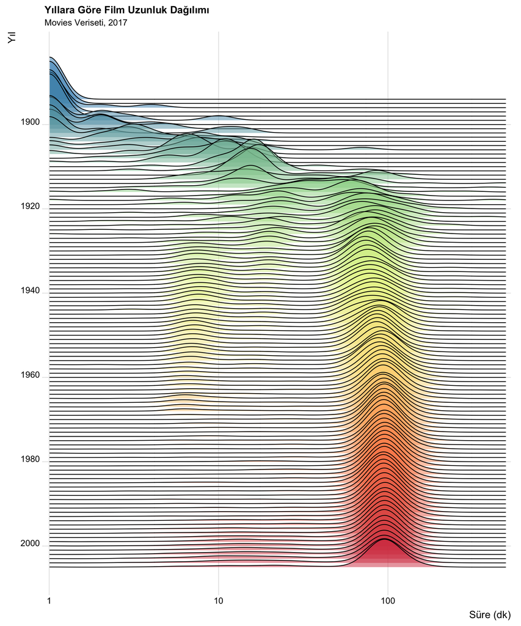

```r
# Örnek 5: Büyük Veri Seti ile Deneme
library(ggplot2movies)

ggplot(data = movies, aes(y=year, x=length, group=year, fill=year)) +
    geom_density_ridges(alpha=0.5, scale=10) +
    scale_x_log10(limits=c(1,500),expand = c(0.01, 0)) +
    scale_y_reverse(breaks=(seq(1900,2000,20))) +
    theme_ridges() +
    theme(legend.position = "none") +
    scale_fill_distiller(palette = "Spectral") +
    labs(title="Yıllara Göre Film Uzunluk Dağılımı",
         subtitle="Movies Veriseti, 2017",
         x="Süre (dk)",
         y="Yıl")
```

Grafikten de anlaşılacağı üzere, film sürelerinin zamanla standartlaşıp 100 dk’da sabitlendiğini; ayrıca son zamanlarda kısa filmlerin de popülerleşmeye başladığını görebiliyoruz.

Yakın zamanda ggplot ile ileri veri görselleştirme hakkında birkaç yazı daha paylaşacağım. Orada, bu gösterim şekline daha detaylı değineceğim. Şimdilik sadece paketi tanıtmış olayım.

**Can Holyavkin**

E-posta | [Linkedin](https://www.linkedin.com/in/can-holyavkin/) | [Twitter](https://twitter.com/CanHolyavkin)